# Analysis of bikeshare data

Andrew Stephens

23 Oct 2020

The goal of this analysis is to provide some prelimiary analysis on the bike share data for August 2020, primarily through visualization.

## Prepare workspace:

#### Load packages

We will work primarily within the context of the tidyverse set of packages, with a few additional packages supporting exploratory analysis. I have included the `lubridate` package, as we will want to do some work with dates.

```r
library(tidyverse)
library(janitor)
library(readxl)
library(skimr)
library(summarytools)
library(lubridate)
```

I will also set a default theme for my ggplots.

```r
theme_set(theme_minimal())
```

## Data

I am **not** using the file that (a) started on moodle for which we, (b) computed a couple of extra variables (for duration, hour of day, and day of week), and (c) saved as .xlsx file.

The orginal source of the data was the csv file

https://s3.amazonaws.com/capitalbikeshare-data/202008-capitalbikeshare-tripdata.zip

so I will use that original source data so that my research is more *reproducible*.

> Note 1: My variable names might be different than yours. Be careful to think through what I am doing and use it as a template.

### Read the data

```r
dfa= read_csv("202008-capitalbikeshare-tripdata.csv") %>%
  clean_names() %>%
  mutate(duration=as.numeric((ended_at-started_at)/60),
         hour_of_day=hour(started_at),
         day_of_week=wday(started_at,label = T))
```

We summarize that dataframe to identify data types, missing data, et cetera.

```r
skim(dfa)
```

```
-- Data Summary ------------------------
                           Values
Name                       dfa
Number of rows             251543
Number of columns          16
_______________________
Column type frequency:
  character                5
  factor                   1
  numeric                  8
  POSIXct                  2
________________________
Group variables            None

-- Variable type: character -----------------------------------------
# A tibble: 5 x 8
  skim_variable      n_missing complete_rate   min   max empty
* <chr>                  <int>         <dbl> <int> <int> <int>
1 ride_id                    0         1        16    16     0
2 rideable_type              0         1        11    13     0
3 start_station_name     15880         0.937    10    61     0
4 end_station_name       18373         0.927    10    61     0
5 member_casual              0         1         6     6     0
  n_unique whitespace
*    <int>      <int>
1   251543          0
2        2          0
3      605          0
4      607          0
5        2          0

-- Variable type: factor --------------------------------------------
# A tibble: 1 x 6
  skim_variable n_missing complete_rate ordered n_unique
* <chr>             <int>         <dbl> <lgl>      <int>
1 day_of_week           0             1 TRUE           7
  top_counts
* <chr>
1 Sat: 51606, Sun: 48568, Fri: 35614, Wed: 30180

```

[output cut: 18 more lines]

```
5  38.9   38.9  38.9    39.3 ▁▇▁▁▁
6 -77.0  -77.0 -77.0   -76.6 ▁▁▇▁▁
7   8.27  15.1  26.4 36978.  ▇▁▁▁▁
8  11     15    18      23   ▁▂▅▇▅

-- Variable type: POSIXct -------------------------------------------
# A tibble: 2 x 7
  skim_variable n_missing complete_rate min
* <chr>             <int>         <dbl> <dttm>
1 started_at            0             1 2020-08-01 00:00:23
2 ended_at              0             1 2020-08-01 00:06:32
  max                 median              n_unique
* <dttm>              <dttm>                 <int>
1 2020-08-31 23:56:58 2020-08-17 05:20:58   232447
2 2020-09-03 13:35:08 2020-08-17 06:10:12   231289
```

#### A histogram - like we did in class

As we discussed in class, we might be interested in looking at histogram of durations, broken out for each day of the week. Here I filter to positive duration shorter than 100 minutes.

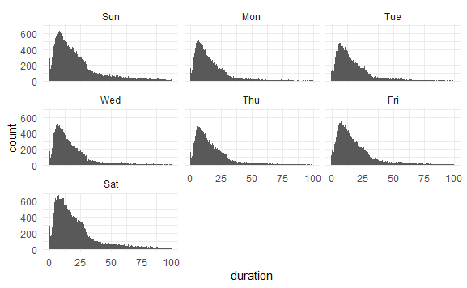

```r
dfa %>% filter(duration<100,duration>0) %>%
  ggplot(aes(x=duration)) + geom_histogram(bins = 300)+facet_wrap(~day_of_week)
```

### Cleaning

Before we do further analysis, we recognize that if the duration is negative, some piece of the time data is corrupt. Although it sill reduce the size of our dataset, it is very much large enough to permit continued analysis even after removing those rows.

Limit to durations that are positive.

```r
dfb=dfa %>% filter(duration>0)
```

### Some visual exploration.

Can a scatterplot be revealing? Many possibilities, but I have decided to focus on “short” trips (duration less than an hour) for a particular day (the 3rd day of the month).

Does the trip duration have a pattern when plotted vs. starting time?

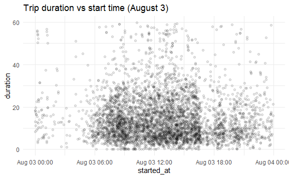

```r
dfb %>% filter(mday(started_at)==3,duration<60) %>% ggplot(aes(x=started_at,y=duration))+
  geom_point(alpha=.1)+
  ggtitle("Trip duration vs start time (August 3)")
```

### Riders vs time

Let’s try to construct a dataframe that could track number of riders (at any instant in time), where we will assume (not reasonably) that there were no riders at 00:00.

I will develop (and test) the logic on a small set of data.  
A small dataset works fast and is easy to read.  
Once we build the logic for the small set, it is easy to generalize.

The `slice_sample` command below takes a random sample of 100 rows. So … my experimental dataframe, `dfe`, limits to the 3rd day of the month, and only 100 rows.

```r
dfe=dfb %>% filter(mday(started_at)==3) %>% slice_sample(n=100)
```

#### Designing an algorithm

Now lets build a process. I will proceed step by step (copying and pasting to add one new step to my process until I get what I want).

I think we only need start and end times.

```r
dfe %>% select(start=started_at,end=ended_at)
```

| start | end |
| --- | --- |
| 2020-08-03 11:02:15 | 2020-08-03 11:26:09 |
| 2020-08-03 21:27:35 | 2020-08-03 21:34:52 |
| 2020-08-03 10:10:30 | 2020-08-03 10:20:14 |
| 2020-08-03 10:25:29 | 2020-08-03 10:41:39 |
| 2020-08-03 23:32:43 | 2020-08-03 23:45:55 |
| 2020-08-03 11:29:30 | 2020-08-03 11:54:08 |
| 2020-08-03 15:48:20 | 2020-08-03 16:12:46 |
| 2020-08-03 12:14:44 | 2020-08-03 12:18:30 |
| 2020-08-03 09:57:00 | 2020-08-03 10:08:59 |
| 2020-08-03 09:36:05 | 2020-08-03 09:47:21 |

[output cut: 90 more lines]

Create a long dataset

```r
dfe %>% select(start=started_at,end=ended_at) %>%
  pivot_longer(start:end)
```

| name | value |
| --- | --- |
| start | 2020-08-03 11:02:15 |
| end | 2020-08-03 11:26:09 |
| start | 2020-08-03 21:27:35 |
| end | 2020-08-03 21:34:52 |
| start | 2020-08-03 10:10:30 |
| end | 2020-08-03 10:20:14 |
| start | 2020-08-03 10:25:29 |
| end | 2020-08-03 10:41:39 |
| start | 2020-08-03 23:32:43 |
| end | 2020-08-03 23:45:55 |

[output cut: 190 more lines]

Pick good names, then order by time.

```r
dfe %>% select(start=started_at,end=ended_at) %>%
  pivot_longer(start:end, names_to="type",values_to="t") %>% arrange(t)
```

| type | t |
| --- | --- |
| start | 2020-08-03 01:23:11 |
| end | 2020-08-03 01:28:42 |
| start | 2020-08-03 02:12:49 |
| end | 2020-08-03 02:49:57 |
| start | 2020-08-03 04:06:52 |
| start | 2020-08-03 04:36:36 |
| end | 2020-08-03 04:50:30 |
| end | 2020-08-03 04:59:04 |
| start | 2020-08-03 05:38:32 |
| start | 2020-08-03 05:50:09 |

[output cut: 190 more lines]

I want to build a counter to track riders, where each “start” increases the count, and each end “decrease” the count.

Additionally, I will want my to `arrange` my rows using my time `t` column.

```r
dfe %>% select(start=started_at,end=ended_at) %>%
  pivot_longer(start:end, names_to="type",values_to="t") %>% arrange(t) %>%
  mutate(increment=case_when(
   type=="start"~1,
   type=="end" ~ -1
  ))
```

| type | t | increment |
| --- | --- | --- |
| start | 2020-08-03 01:23:11 | 1 |
| end | 2020-08-03 01:28:42 | -1 |
| start | 2020-08-03 02:12:49 | 1 |
| end | 2020-08-03 02:49:57 | -1 |
| start | 2020-08-03 04:06:52 | 1 |
| start | 2020-08-03 04:36:36 | 1 |
| end | 2020-08-03 04:50:30 | -1 |
| end | 2020-08-03 04:59:04 | -1 |
| start | 2020-08-03 05:38:32 | 1 |
| start | 2020-08-03 05:50:09 | 1 |

[output cut: 190 more lines]

Now lets cummulative sum that column.

```r
dfe %>% select(start=started_at,end=ended_at) %>%
  pivot_longer(start:end, names_to="type",values_to="t") %>% arrange(t) %>%
  mutate(increment=case_when(
   type=="start"~1,
   type=="end" ~ -1
  )) %>%
  mutate(riders=cumsum(increment))
```

| type | t | increment | riders |
| --- | --- | --- | --- |
| start | 2020-08-03 01:23:11 | 1 | 1 |
| end | 2020-08-03 01:28:42 | -1 | 0 |
| start | 2020-08-03 02:12:49 | 1 | 1 |
| end | 2020-08-03 02:49:57 | -1 | 0 |
| start | 2020-08-03 04:06:52 | 1 | 1 |
| start | 2020-08-03 04:36:36 | 1 | 2 |
| end | 2020-08-03 04:50:30 | -1 | 1 |
| end | 2020-08-03 04:59:04 | -1 | 0 |
| start | 2020-08-03 05:38:32 | 1 | 1 |
| start | 2020-08-03 05:50:09 | 1 | 2 |

[output cut: 190 more lines]

I think that is what I need. I will visualize (using a step plot) to see if it makes sense. I simply … continue the pipe.

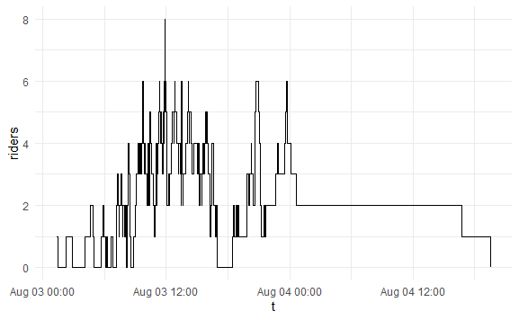

```r
dfe %>% select(start=started_at,end=ended_at) %>%
  pivot_longer(start:end, names_to="type",values_to="t") %>% arrange(t) %>%
  mutate(increment=case_when(
   type=="start"~1,
   type=="end" ~ -1
  )) %>%
  mutate(riders=cumsum(increment)) %>%
  ggplot(aes(t,riders)) + geom_step()
```

#### Analysis without sampling:

Now … let’s examine all the data for August 3rd. I simply need to drop in the dataframe for August 3rd *without* doing the steps that select a random sample, but *otherwise using the exact commands developed above.*

For the visualization, I will limit to only 3 August, which is a bit tricky.

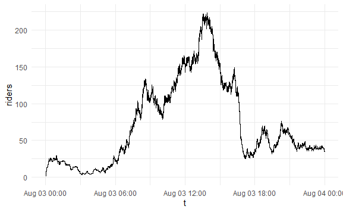

```r
dfb %>% filter(mday(started_at)==3) %>%
  select(start=started_at,end=ended_at) %>%
  pivot_longer(start:end, names_to="type",values_to="t") %>% arrange(t) %>%
  mutate(increment=case_when(
   type=="start"~1,
   type=="end" ~ -1
  )) %>%
  mutate(riders=cumsum(increment)) %>%
  ggplot(aes(t,riders)) + geom_step() +
  scale_x_datetime(limits=as_datetime(   c("2020-08-03","2020-08-04")))
```

We could look at the whole dataset. All we have to do is *not* do that filtering step … and let the axis cover the whole range.

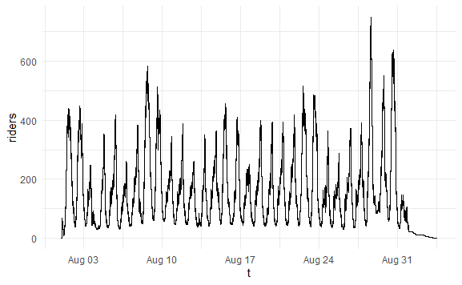

```r
dfb %>%
  select(start=started_at,end=ended_at) %>%
  pivot_longer(start:end, names_to="type",values_to="t") %>% arrange(t) %>%
  mutate(increment=case_when(
   type=="start"~1,
   type=="end" ~ -1
  )) %>%
  mutate(riders=cumsum(increment)) %>%
  ggplot(aes(t,riders)) + geom_step()
```

I think this is interesting, but I think I can improve using faceting, to separate out for each day of the month. I will facet by 7 columns so that days of the week are aligned. For these facets, I use the option “free_x” as each facet is covering a different time range.

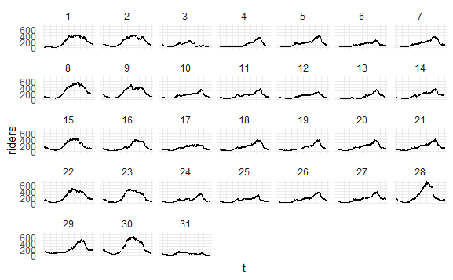

```r
dfb %>%
  filter(month(started_at)==8,month(ended_at)==8) %>%
  select(start=started_at,end=ended_at) %>%
  pivot_longer(start:end, names_to="type",values_to="t") %>% arrange(t) %>%
  mutate(increment=case_when(
   type=="start"~1,
   type=="end" ~ -1
  )) %>%
  mutate(riders=cumsum(increment)) %>%
  ggplot(aes(t,riders)) + geom_step() +
  facet_wrap(~mday(t),scales = "free_x",ncol = 7) +
  theme(axis.text.x = element_blank())
```

#### Separating electric and docked bikes

To consider by type of bike, we will need “cumsum” to be working separately on “electric bikes” and “docked bikes”. Which means:

- We have to include that variable in the dataset, and
- We will need to group on that variable

For this visualization, although I do the compuation for the whole month, I will show only the first 7 days of August.

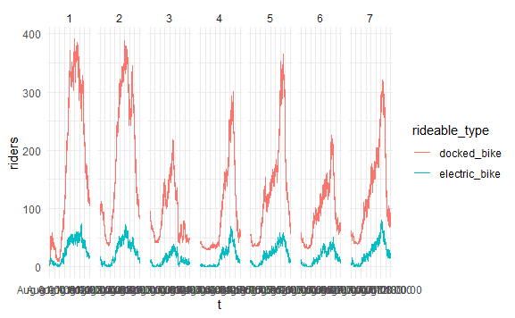

```r
dfb %>%
  filter(month(started_at)==8,month(ended_at)==8) %>%
 select(rideable_type,start=started_at,end=ended_at) %>%
  pivot_longer(start:end, names_to="type",values_to="t") %>% arrange(t) %>%
  mutate(increment=case_when(
   type=="start"~1,
   type=="end" ~ -1
  )) %>%
  group_by(rideable_type) %>%
  mutate(riders=cumsum(increment)) %>% filter(mday(t)<=7) %>%
    ggplot(aes(t,riders,color=rideable_type)) + geom_step() +
  facet_wrap(~mday(t),scales = "free_x",ncol = 7)
```

### Box and whisker plot for trip duration based on “hour”.

Because I said we could. Note - I specified “hour of day” as a grouping variable.

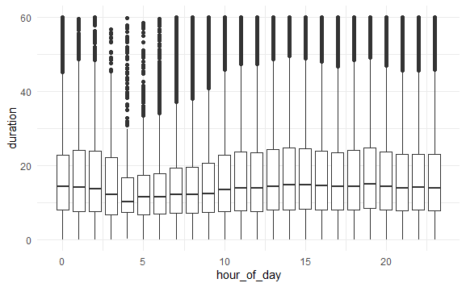

```r
dfb %>% filter(duration<60) %>% ggplot(aes(x=hour_of_day,y=duration,group=hour_of_day)) +
  geom_boxplot()
```

Continued in class 10/21

How many riders (max) in any hour interval?

```r
dfrh = dfr1 %>% group_by(wday(t,label=T),hour(t)) %>%
  summarise(max_riders = max(riders),ave_riders = mean(riders))
```

[output not shown]

Which stations “gain” bikes over time and which ones “lose” bikes?

```r
net = gains %>% full_join(losses) %>%
  replace_na(list(starts = 0)) %>%
  group_by(station_id) %>%
  mutate(net_gains = starts - ends)
```

Visualize these results to see how the net gains of each station compare to one another

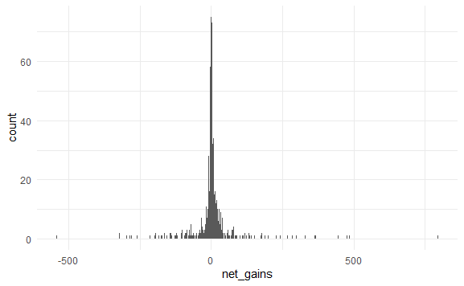

```r
net %>% ggplot(aes(x=net_gains)) +
  geom_histogram(bins = 500)
```